# Prolog: Statistics, Computer & Women Who Code

Prof. Dominik Liebl

## A server farm in the 1920s

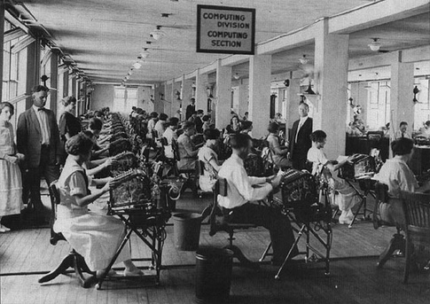

## Women Who Code

Throughout the 19th and early 20th century, and up to World War II, **programming was predominantly done by women**; significant examples include

- [the Harvard Computers](https://en.wikipedia.org/wiki/Harvard_Computers),
- [codebreaking](https://en.wikipedia.org/wiki/Bletchley_Park) at [Bletchley Park](https://en.wikipedia.org/wiki/Women_in_Bletchley_Park) and
- [engineering at NASA](https://en.wikipedia.org/wiki/Women_in_NASA).

Sources:

- https://en.wikipedia.org/wiki/Women_in_computing
- https://en.wikipedia.org/wiki/Gender_disparity_in_computing

## Women Who Code

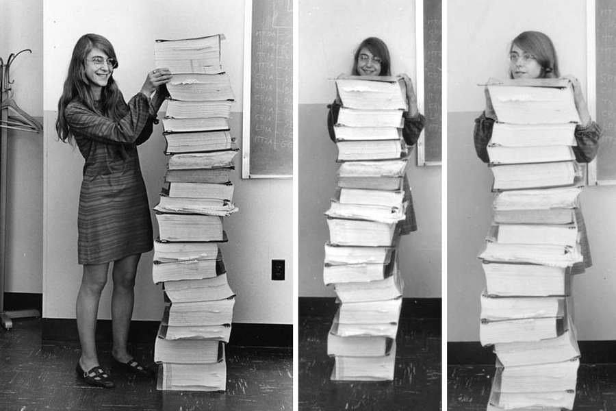

The NASA sent a man to the moon, but it was a woman’s code that got the guy there: **Margaret Hamilton!**

## The Computer Revolution

**Fun fact:** One of the most famous of all failures of foresight is the quoted remark of Thomas Watson, then Chairman of IBM, in 1943 that:

“I think there is a world market for maybe **five** computers” 😂

## Statistics and the Computer

The computer is changing the field of statistics in three different ways:

1. Computers can help us to do what we did before, but more **efficiently**. 💪
2. Computers can help us to do things **nobody thought of before** the advent of the computer. 🤯
3. Computers can help us to **understand statistics**. 🤓

## **1. Efficiency** 💪

‘When I was a PhD student inverting a 5 × 5 matrix was the work of 3 hours’. (David Cox, 1949)

- Today’s Datasets:
  - Insurance (66 million drivers $\approx$ 1/3 of all US drivers.)
  - Sales from Amazon
  - [fMRI maps](http://journals.plos.org/plosone/article?id=10.1371/journal.pone.0089470): 100,000 voxels per session, with often less than 100 sessions.

A Word of Caution: ‘Large’ is not equivalent to ‘Good’!

## **2. Nobody Thought of Before** 🤯

**The Unthinkables (according to Bradley Efron):**

- Monte Carlo Simulation
- Bootstrap (and all its derivatives)
- Nonparametric Statistics
- Cross-Validation
- Maximum Likelihood
- LASSO, Ridge-Regression, etc.

Source: [Computers and the Theory of Statistics: Thinking the Unthinkable](https://statistics.stanford.edu/sites/default/files/BIO%2039.pdf) by **Bradley Efron**

## **3. Understanding Statistics via Coding** 🤓

- Prof. D. G. Kendall:  
  ‘You don’t really understand a stochastic process until you know how to simulate it.’
- Expanded by Prof. B. Ripley:  
  ‘You don’t really know how to simulate a stochastic process until you have done so and validated your simulations.’

## The Role of Software

- Increase in computational speed is fantastic, but only **software** makes it accessible.
- (By far) most incorrect statistical analyses result from **user error rather than incorrect software**, but the latter is often not even considered.
- [The mysterious powers of Microsoft Excel](https://www.bbc.com/news/magazine-22213219)

## **Incorrect Software**

[figure not shown]

Source: https://www.economist.com/graphic-detail/2016/09/07/excel-errors-and-science-papers

## Lecture Material

[https://www.dliebl.com/Script-CompStat-MSc/](https://www.dliebl.com/Script-CompStat-BSc/)

pwd: `compstat`

Link is also provided via eCampus